# 607 Week 5

Lu Beyer

# Overview:

I am working to transform this data on Alasaka and AM West airline flight delays to more easily compare the airlines based on their on-time and delayed flights.

Load Data

```r
library(tidyverse)
```

Make all blank cells “NA”

```r
x <- read.csv("607_airline_dirty.csv", na.strings = c("", "NA"))
```

Consolidated destinations into a single destination column

```r
y <- x %>%
  pivot_longer(
    cols = c(Los.Angeles, Phoenix, San.Diego, San.Francisco, Seattle),
    names_to = "Destination",
    values_to = "Flights",
    values_drop_na =  TRUE
  ) %>%
  rename(Airline = X, Delay_status = X.1) %>%
  fill(Airline, .direction = c("down"))
```

I did not need to do this, but created a df of on time-flights

```r
on_time <- y %>%
  filter(Delay_status == "on time")
```

I tried to evaluate the data based on on-time flights, but realized there was a big difference in overall flight totals between both airlines

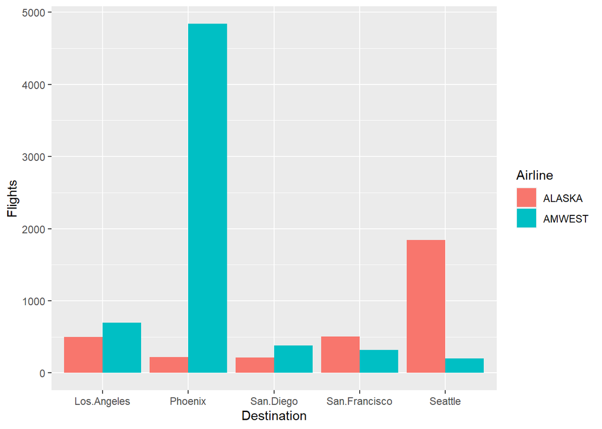

```r
ggplot(data = on_time, aes(x = Destination, y = Flights, fill = Airline)) +
  geom_bar(position = "dodge", stat = "identity")
```

```r
delayed <- y %>%
  filter(Delay_status == "delayed")
```

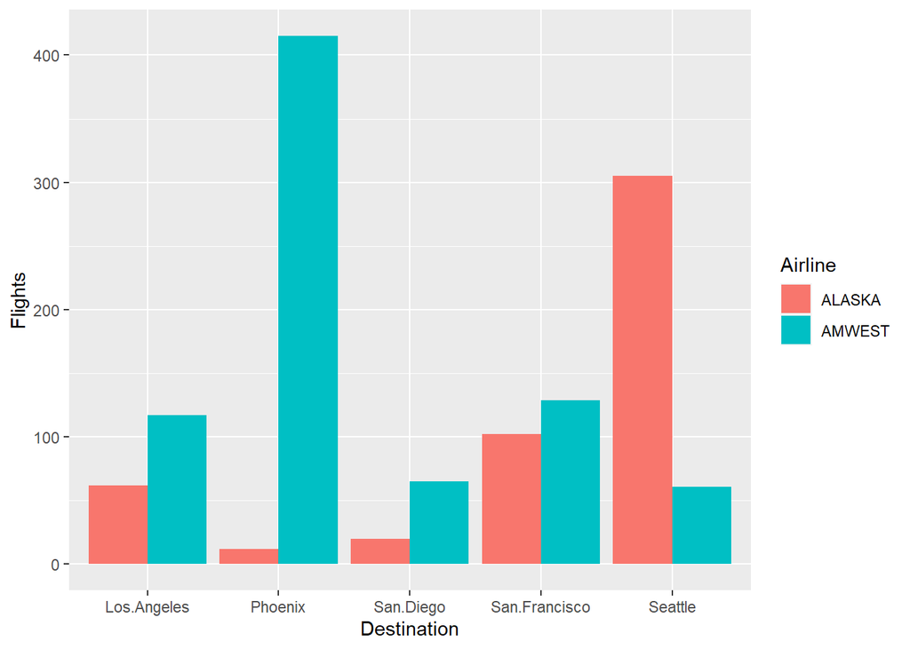

```r
ggplot(data = delayed, aes(x = Destination, y = Flights, fill = Airline)) +
  geom_bar(position = "dodge", stat = "identity")
```

I decided to try to evaluate the data based on flight delay status percentages, I grouped by Airline and Delay status to get a total flight count, and then calculated the flight delay percentages based on those totals.

```r
z <- y %>%
  group_by(Airline, Delay_status) %>%
  summarise(Flights_count = sum(Flights)) %>%
  ungroup() %>%
  group_by(Airline) %>%
  mutate(Total_flights = sum(Flights_count)) %>%
  mutate(Percentage = Flights_count/Total_flights)
```

I created a bar graph to help visualize those percentages of on-time and delayed flights between both airlines

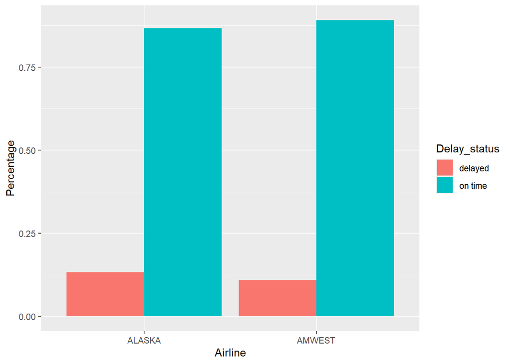

```r
ggplot(data = z, aes(x = Airline, y = Percentage, fill = Delay_status)) +
  geom_bar(position = "dodge", stat = "identity")
```

```r
wider_y <- y %>%
  pivot_wider(names_from = Delay_status, values_from = Flights) %>%
   rename(on_time = `on time`) %>%
  group_by(Airline, Destination) %>%
  mutate(total_flights = sum(on_time, delayed)) %>%
  mutate(on_time_rate = on_time / total_flights) %>%
  mutate(delay_rate = delayed / total_flights)
```

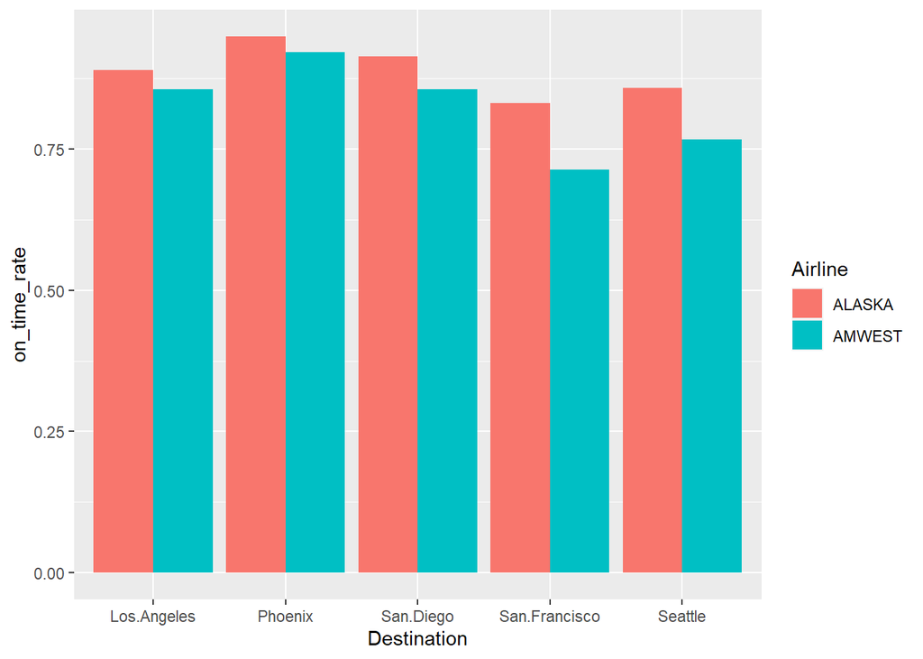

```r
ggplot(data = wider_y, aes(x = Destination, y = on_time_rate, fill = Airline )) +
  geom_bar(position = "dodge", stat = "identity")
```

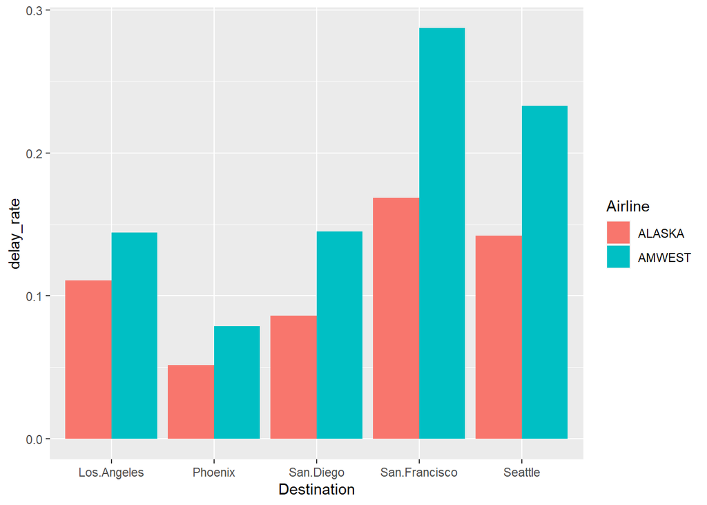

```r
ggplot(data = wider_y, aes(x = Destination, y = delay_rate, fill = Airline )) +
  geom_bar(position = "dodge", stat = "identity")
```

# Conclusion:

Based on the plot showing the overall flights status of both airlines, it seems that AM west is a better airline to fly out of because they have more flights and an overall lower percentage of delayed flights and a higher percentage o online flights, however, when separating the data by destination from each airline, we see AM west has a higher percentage of delayed flights out of each destination than Alaska. So while they both tend to run on-time more than they are delayed, out of each destination, Alaska Airlines have a lower percentage of their flights being delayed than AM West.